# How many people voted on the 1st of October independence referendum?

A bootstrap approach using a quota sample survey.

Josep Espasa Reig

# Acknowledgements

This blog couldn’t have been writen without the scripts published by the authors of Sturgis et al 2017 [^1] and the responses to my technical questions provided by people at [‘Centre d’Estudis d’Opinió’ (CEO)](http://ceo.gencat.cat/ca/inici/index.html).

# How many people voted?

The official data offered by the Catalan Government a few days after the independence referendum registered a turnout of almost 2.3 million votes or 43.03% of the census [^2]. This count, however, missed the polls that were seized by Spanish police forces. The by then Catalan Government spokesman, said that, under ‘normal circumstances’, participation could have easily reached 55% [^3].

The real number of votes is thus still unknown, and very little data from surveys on this issue is publicly available. The main exception to this is the [‘Centre d’Estudis d’Opinió’ (CEO)](http://ceo.gencat.cat/ca/inici/index.html) ‘barometer’ survey. To my knowledge, this poll is the only one that asked respondents about their participation on the 1-O referendum.

The CEO survey, collected data during the last two weeks of that month and used a quota sampling with sample allocation proportional to population estimates [^4]. The proportional allocation meant that the sample size in three out of the four provinces was too small to compute reliable estimates. The sample size of the Province of Barcelona, however, was close to 1,000 respondents and should allow for a decent calculation [^5].

According to the official information from the Catalan Government the province had a turnout of 41.2% or around 1,6 million votes. As shown in Figure 1, my estimate from CEO survey data would be that the turnout was most likely between 50.6% and 56.8%. This would mean that between 2 and 2.26 million people voted in this province.

Even knowing that some polls were taken away by Spanish police forces, the difference between the official information and the CEO survey is large. Thus, estimates from the survey should be taken with a grain of salt. We know that people tend to lie about their participation in elections, stating that they voted when they actually didn’t[^6]. Moreover, a quota sample like the one used by CEO is based on assumptions that might have been violated in this case. These assumptions and the exact methods used to compute the estimates are explained in the next sections in a slightly more technical way.

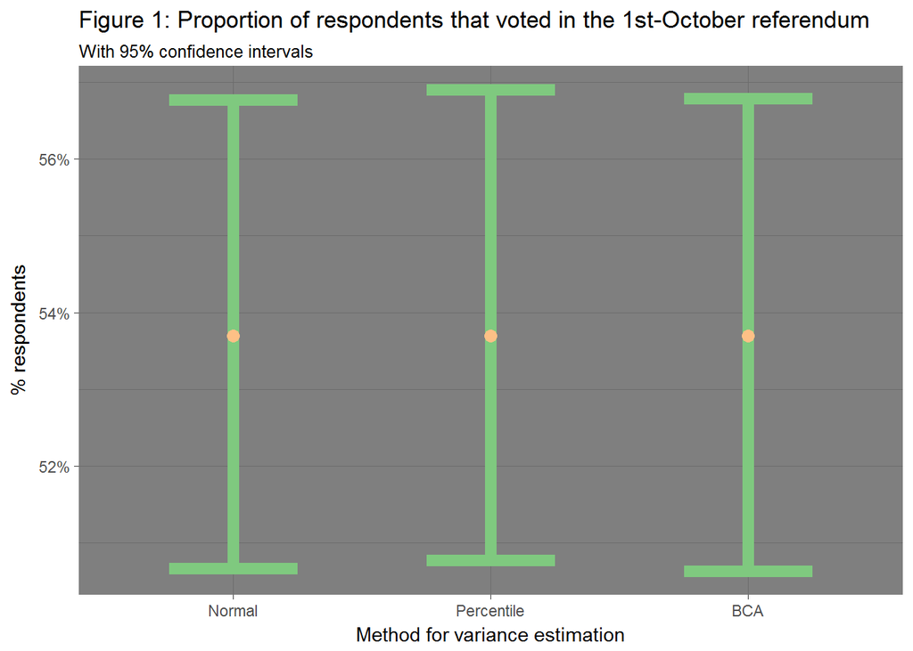

# Quota sampling

Before explaining the particluarities of quota sampling, let me give a brief overview about the concepts of probability and non-probability sampling.

## Probability vs non-probability sampling

Concisely explained, there are two types of survey sampling: probability sampling and non-probability sampling. In the survey industry the first one is still the gold standard. In probability sampling, we draw a random sample of units from a population. We know the probability of each unit being selected. The probability of inclusin should not be equal to 0 for any unit, having all of them a chance to be in the survey. The great advantage of probability sampling is that they are unbiased. This is, if the sampling was to be repeated many times, the expected value of the estimates from the samples would be identical to the value for the whole population. Thus, the sample will tend to be (on average) a small-scale representation of the population from which we can obtain unbiased estimates.

Non-probabililty samples are those in which the selection of units is not randomised according to principles of probability theory. There is a wide variety of non-probability sample methods [^7]. They are extensively used in market research but considered of poor quality in many fields. When compared to probability sample surveys, they don’t have the ‘unbiasedness’ characteristic by design. Thus, this type of surveys tend to depend a lot on adjustments made by statisticians once the sample is collected.

Three main issues of probabilty samples are coverage error, non-response error and their cost. The first two are problems that affect the capacity of the sample to properly represent the population. Coverage error is caused by some units not being in the list from which the random sample is selected[^8]. Non-response error is when the survey fails to collect responses for some of the units. This increases the uncertainty of estimates due to smaller sample sizes and risks biasing the survey as certain profiles of respondents might have a larger propensity to respond than others. Some statisticians have pointed that, due to non-response, no survey is really a probability sample [^9]. The same voices say that the low response rates that we see in certain research areas might make probability samples worthless.

## Quota sampling and the CEO survey

In this particular survey, some quotas could not be filled because of low response rates and budget constrains. Thus, CEO applied a calibration step after the responses were collected.

The main problem with quota sampling is that the selection of respondents within quotas is not randomised. Therefore, the estimates from the survey will be biased if respondents within quotas differ from those in the population. The estimation of the proportion of people that voted in the 1-O referendum will be biased if, within each quota (e.g. males, 18 to 24 born in Catalonia), the proportion of people that voted isn’t the same as that in the population for people with the same characterisctics.

## Variance estimation for quota sampling

As important as providing an estimate of the proportion of people that voted is the capacity to provide an estimate of it’s uncertainty. This means that we don’t only want to know how many people voted, but how confident we are on this estimate. This is the point where methodology gets more tricky and the actual reason why I started doing this analysis.

Most researchers compute the uncertainty of estimates as if the data proceeded from simple random samples from the population [^11]. Thus, they do not take into account the actual design of the survey. Sturgis et al. (2017) suggests a method for calculation the precision of estimates from quota samples. This method is based on ‘bootstrap resamples’ or resamples with replacement taken from the survey data. In their article, Sturgis et al. explain it in the following way:

> 1. draw M independent samples by sampling respondents from the full achieved sample, with replacement and in a way which matches the quota sampling design;
> 2. for each sample thus drawn, calculate the point estimates of interest in the same way as for the original sample, including calibration and turnout weighting;
> 3. use the distribution of the estimates from the M resamples to quantify the uncertainty in the poll estimates.

## Estimation of 1-O turnout using bootstrap resamples

To estimate the participation in the 1-O referendum using the CEO sample I used the method proposed in Sturgis et al. (2017) and the R code accompaining the article. The scripts with the code for this analysis can be found in the [GitHub repository for this article](https://github.com/JosepER/CEO_public/tree/master/scripts). Summarising the process, after cleaning and rearranging the data I computed the bootstrap resamples simulating 10,000 different samples with the quota design. The analysis of these resamples should represent the variablility in the quota sampling process if this was to be implemented a large number of times. An important difference with the original sampling design is that I included the size of municipalities as another quota. Ideally, there should probably be first a step with a resample of municipalities[^12]. The publicly available data, however, didn’t have an identification variable for all municipalities.

Once the bootstrap resamples were drawn, I calibrated them using official statistics data from IDESCAT, the official body responsible for collecting and publishing statistics in Catalonia.